# **A Paradoxical World**

A 73 project by Suzie, Electra, Georgina and Mingyou. Illustrates some common paradoxes in statistcal analysis.

*Before we dive into individual paradoxes, let's get some groundwork done by learning about general concepts in statistics and how they relate to paradoxes.*

## Types of variables

**Introducing numerical variables**

Numerical variables take numerical values for which arithmetic operations such as adding and averaging make sense. Sometimes called quantitative data, numerical data is always collected in number form. Numerical data differentiates itself from other number form data types with its ability to carry out arithmetic operations with these numbers. Age(years), mass(kg), and height(m) are some examples of numerical variables.

Numerical data can take 2 different forms:

1. **Discrete variable**: One where certain possible values of the variable form a set of numbers with “gaps”. E.g. Population count
2. **Continuous variable**: One that can take on all possible numerical values in a given range or interval. E.g. Time, length

**Introducing categorical variables**

A categorical variable is a discrete variable that takes on categories or label values. The categories or labels are mutually exclusive, meaning that an observation cannot be placed in the same category or given two different labels at the same time.

Among categorical variables, there are generally two sub-types.

1. **Ordinal variable**: Categorical variable where there is some natural ordering and numbers can be used to represent the ordering. Common examples include income level, socio-economic status, education level and satisfaction rating. Even though represented in number form, the label values have an inherent meaning and thus cannot have arithmetic operations performed on them.
2. **Nominal variable**: Categorical variable where there is no intrinsic ordering. Examples include name, hair colour, race, gender etc.

## Associations between variables

### By level: sample level/ population level

Associations can be identified at the sample level with 100% certainty. Meanwhile, identifying associations at the population level requires extrapolation of sample data, which means any associations identified in the sample is not 100% certain to remain in the population.

For discrete variables (both numerical and categorical variables) specifically, the rate of occurrence is used as a summary statistics to characterise the variable at the sample level. However at the population level, unless there is data on the whole population, summary statistics are not available and thus need to be predicted from summary statistics of samples. Thus probability of occurrence is used instead.

### By type of variable

**Associative relationships between numerical variables**

In general, we can identify positive, negative, or no association between two numerical variables. Because each numerical variable is characterised by a range of values (even for discrete variables), there is inherent directionality to the values of the variables and thus associations can be made between two numerical variables.

To make sense of the explanation above, let's take a simple example: supposedly, the number of hours spent on studying is positively associated with the chance of having depression. This means that the **higher** (directional) the number of hours of study, the **greater** (directional) the chance of having depression.

**Associative relationships between categorical variables**

In general, we can identify positive, negative, or no association between values of categorical variables, instead of association between the variables themselves.

Let A and B be a label value of two categorical variables α and β respectively. A' means 'not A' - another label value of the variable α. B' means 'not B' - another label value of the variable β. The notation rate(A|B) means rate of occurence of A given B.

We say that **A and B are positively associated** if **rate(A|B) > rate(A|B') or rate(B|A) > rate(B|A')**.

Conversely, we say that **A and B are negatively associated** if **rate(A|B) < rate(A|B') or rate(B|A) < rate(B|A')**.

Finally, we say that **A and B are not associated** if **rate(A|B) = rate(A|B') = 0.5**.

*In case there are more than two values for a categorical variable, association can only be formed when comparing pairs of values for a variable (e.g. variable α has values A0, A1, A2, variable β has values B0 and B1 -> a possible association: between A0 and B0, against A1 and B0 or A0 and B1 as the baseline: A = A0, B = B0, A' = A1, B' = B1. This means that if A0 and B0 are positively associated, A1 and B0 must be negatively associated, A0 and B1 must be negatively associated, A1 and B1 must be positively associated)*

## **Paradoxes**

However, complexities arise in studying association between variables.

A confounder is a third variable that is associated with both the independent and dependent variables whose relationship we are investigating. The presence of confounding variables can distort the associative relationship between the two main variables we are investigating, and may also cause the observation of paradoxes.

Observation bias and sub-group differences can easily produce statistical paradoxes in any data science application. Ignoring these elements can therefore completely undermine the conclusions of our analysis.

Statistical paradoxes are dangerous because if not identified during data analysis, it can result in drawing wildly incorrect conclusions from the observed trends.

In this project, we aim to analyze 3 statistical paradoxes and use Python to model them, to find generalisable patterns amongst multiple datasets if possible.

# Loading dependencies

Let's start by loading all the packages we will need for this project right now so as not to clutter our code with import commands.

```python
import numpy as np
import pandas as pd
from matplotlib import pyplot as plt
from random import randint
import seaborn as sns
from sklearn.datasets import make_blobs
from sklearn import preprocessing
from numpy.random import multivariate_normal, seed
```

```python
#----------------- Some matplotlib customisations ----------------#

plt.style.use('fivethirtyeight')

# rcParam below holds all the default settings for
# matplotlib plots. We can change the style of ALL
# plots by modifying rcParam

plt.rcParams["figure.figsize"] = (12, 6)      # Set the figsize of ALL my plots
plt.rcParams["axes.labelcolor"] = '#b2182b'
plt.rcParams["axes.titlecolor"] = '#b2182b'
```

# **Simpson's Paradox**

Simpson's Paradox, also known as the Yule-Simpson effect, refers to an effect encountered in probability and statistics where a trend appears in several data groups but disappears or reverses when the groups are combined.

An example of this paradox is obtained from a study investigating the death rate among the COVID-19 patients. The plot below shows the case fatality rates by age group in China versus Italy.

Observe that for all age groups, death rates among Covid-19 patients in Italy are lower than those in China, but the overall death rate among the Covid-19 patients in Italy is higher than that in China.

[figure not shown]

This occurs because the proportion of confirmed cases belonging older age groups (70+) is much higher in Italy compared to in China as shown below. As older confirmed cases have higher fatality, the greater proportion of confirmed cases belonging to older age groups pulls up the overall fatality in Italy, compared to in China.

[figure not shown]

To simplify this problem, let us split the age groups into two big age groups: young [Y] (0-69) and old [O] (70+). In the graphics below, each circle represents either Y or O group (annotated), the position of the centre of each circle corresponds to that group’s death rate. As the circles grow (i.e. group proportions change) we can see how the overall death rate changes.

[figure not shown]

Simpson's Paradox is frequently present in statistics concerning social-science and medical-science, and is problematic when frequency data is wrongly given causal interpretations, thus generating misleading results. To resolve this paradox, confounding variables and causal relations are appropriately addressed in the statistical modeling.

## **Predicting Simpson's paradox**

Since we know that Simpson's paradox is caused by a confounding variable, but the reverse is not necessarily true, we aim to predict Simpson's paradox based on $a)$ the rates of the main variables, conditioning on the confounding variable, $b)$ the strength of association between the confounder and two main variables. We shall be exploring this hypothesis with respect to both types of variables: categorical variables and numerical variables.

### 1) Categorical variables

Because it is difficult to aggregate enough real world datasets for us to perform adequate analysis to form a conclusion of whether there is indeed a relationship between the marginal rates and the possibility of a simpson's paradox, we shall construct an imaginary datasets with the same variables (including the confounder).

The imaginary datasets used shall follow this framework:

1) Variables:

- Type of treatment (X/Y): independent variable
- Outcome of treatment (success/failure): dependent variable
- Size of stone: potential confounding variable

2) Rates to be calculated:

- R(success|X): *to determine the overall trend*
- R(success|X ∩ size of stone), R(success|Y ∩ size of stone): *to determine the trend of sub-groups*
- R(success|size of stone): *to determine degree of association*
- R(X|size of stone): *to determine degree of association*

#### Generate a new dataset with the conditions mentioned

```python
def dataset(seed=1):
  arrays = [['X', 'X', 'Y', 'Y'],
           ['Large', 'Small', 'Large', 'Small']]   # levels of first variable (N1)
  index = pd.MultiIndex.from_arrays(arrays, names=('Treatment', 'Stone size'))
  np.random.seed(seed)
  para = np.random.randint(10000,size=8)  # size = total number of cells = N1 x N2
  df = pd.DataFrame({'Success': para[:4], 'Failure': para[4:]},index=index) # levels of second
                                                                            # variable (N2)
                                                                            # splitting of para
                                                                            # depends on N1
  return df
```

```python
# test output
df=dataset(seed=2)
print(df)
print('Large, Treatment X: Success = ', df.iloc[0, 0])
print('Large, Treatment X: Failure = ', df.iloc[0, 1])
print('Small, Treatment Y, Success = ', df.iloc[3, 0])
```

```
                      Success  Failure
Treatment Stone size
X         Large          7336     1099
          Small          2575     4770
Y         Large          6637      433
          Small          2514     6751
Large, Treatment X: Success =  7336
Large, Treatment X: Failure =  1099
Small, Treatment Y, Success =  2514
```

#### Collect simps(on) :)

```python
def simp(df): #check if simpsons paradox is present
  df=np.array(df)
  if np.sum(df[:2,0])/np.sum(df[:2,:])!=0.5:  # if size of stone is indeed confounder
  # notation format: a_b = rate(a|b), a_b_c = rate(a|b ∩ c)
    success_X = 1 if np.sum(df[:2,0])/np.sum(df[:2,:])>np.sum(df[2:,0])/np.sum(df[2:,:]) else 0 # checks general trend
    success_X_large = 1 if df[0,0]/np.sum(df[0,:])>df[2,0]/np.sum(df[2,:]) else 0 # checks trend in subgroups
    success_X_small = 1 if df[1,0]/np.sum(df[1,:])>df[3,0]/np.sum(df[3,:]) else 0
    if np.all(np.array([success_X_large,success_X_small])!=success_X): # checks reversal of trend
      return 1
    return 0
```

```python
# Test case containing Simpson's paradox:
arrays = [['X', 'X', 'Y', 'Y'],
          ['Large', 'Small', 'Large', 'Small']]
index = pd.MultiIndex.from_arrays(arrays, names=('Treatment', 'Stone size'))
df = pd.DataFrame({'Success': [381,161,55,234],
                   'Failure': [526-381,174-161,80-55,270-234]},index=index)
print(simp(df))
```

```
1
```

```python
eva = simp([[10 for i in range(2)] for j in range(4)])  # test case with no confounder
print(eva)
```

```
None
```

```python
not_Simp = []
Simpsons = []
for i in range(200000):  # generate n number of datasets, beware of runtime
  eva = simp(dataset(seed=i))
  if eva==0:
    not_Simp.append(i)
  elif eva==1:
    Simpsons.append(i)
N = len(Simpsons)
print(Simpsons)         # keeping track of indexes of simpsons paradoxes generated
print(len(Simpsons))    # counting number of Simpsons paradoxes generated
```

```
[136, 204, 231, 305, 369, 445, 914, 1177, 1241, 1258, 1271, 1288, 1303, 1556, 1939, 1988, 2362, 2403, 2694, 2773, 2784, 2893, 3243, 3310, 3324, 3388, 3406, 3565, 3589, 3620, 3628, 3793, 3871, 3894, 3912, 3992, 4064, 4236, 4254, 4444, 4454, 4731, 4814, 4839, 5234, 5513, 5612, 5650, 5790, 5860, 5878, …
1882
```

#### Plot rates and associations

```python
def rates(df):  # returns the rate of each variable, conditioning on confounder
  df=np.array(df)
  success_large = np.sum(df[[0,2],0])/np.sum(df[[0,2],:])
  X_large = np.sum(df[0,:])/np.sum(df[[0,2],:])
  return (success_large,X_large)
```

```python
Simp_rate = []
not_Simp_rate = []
for i in Simpsons:
  Simp_rate.append(rates(dataset(seed=i)))
# N is number of Simpsons paradoxes generated -> use the same number of
# non-Simpsons paradoxes for better visualisation and comparison
for i in not_Simp[0:N]:
  not_Simp_rate.append(rates(dataset(seed=i)))
Simp_rate=np.array(Simp_rate)
not_Simp_rate=np.array(not_Simp_rate)
```

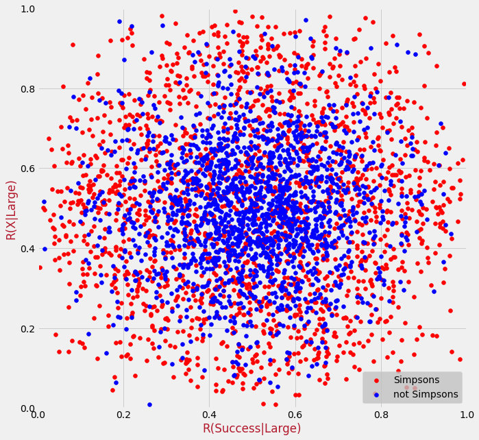

```python
# plots rate of X given large against rate of success given large
# colour of dot: red - Simpsons, blue - no Simpsons
plt.figure(figsize=(10,10))
plt.scatter(Simp_rate[:,0],Simp_rate[:,1],color='r', label='Simpsons')
plt.scatter(not_Simp_rate[:,0],not_Simp_rate[:,1],color='b', label = 'not Simpsons')
plt.xlabel('R(Success|Large)')
plt.ylabel('R(X|Large)')
plt.xlim(0,1)
plt.ylim(0,1)
plt.legend(frameon=True, facecolor='#c2c2c2')
plt.show()
```

#### Plot strength of association

The measure of strength of association of main variables with the confounding variable in this case would be the the Phi coefficient ($\phi$), whose calculation is specified by the formula below.

\begin{equation} \phi = \dfrac{AD - BC}{\sqrt{(A+B)(C+D)(A+C)(B+D)}} \end{equation}

> where $A,B,C,D$ are counts of combinations of two categorical variables, each having two values, following the table below:

[figure not shown]

$\phi$ is interpreted in the following way:

- -1 < $\phi$ < 0: the two 'value 1's are negatively associated
- $\phi$ = 0: two variables are not related
- 0 > $\phi$: the two 'value 1's are positively associated

Applying this to the imaginary datasets we have constructed, we can find the strength of association between the confounder and each of the two main variables.

```python
# formula to calculate phi coefficients
def phi(df):
  [[A,B],[C,D]] = np.array(df)
  return (A*D - B*C)/np.sqrt((A+B)*(C+D)*(A+C)*(B+D))
```

```python
# rearranging dataset into two 2x2 tables and calculating corresponding phi cofficients
def ass(df):
  df = np.array(df)
  success_large_df = [df[0]+df[2],df[1]+df[3]]
  X_large_df = [df[:2,0]+df[:2,1],df[2:,0]+df[2:,1]]
  success_large = phi(success_large_df)
  X_large = phi(X_large_df)
  return (success_large,X_large)
```

```python
Simp_ass = []
not_Simp_ass = []
for i in Simpsons:
  Simp_ass.append(ass(dataset(seed=i)))
# N is number of Simpsons paradoxes generated -> use the same number of
# non-Simpsons paradoxes for better visualisation and comparison
for i in not_Simp[0:N]:
  not_Simp_ass.append(ass(dataset(seed=i)))
Simp_ass=np.array(Simp_ass)
not_Simp_ass=np.array(not_Simp_ass)
```

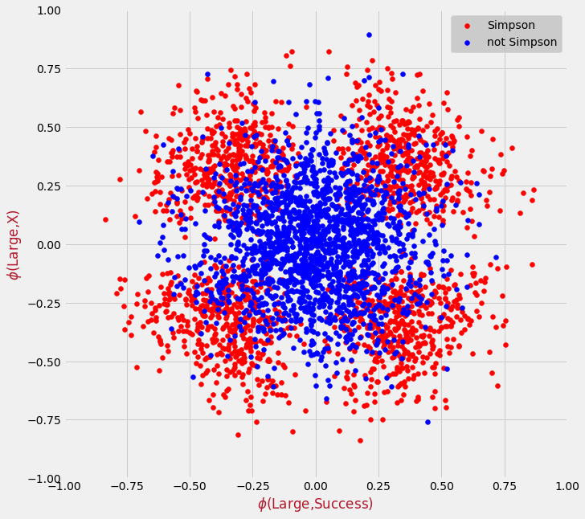

```python
# plots a pair of phi coefficients for each dataset
plt.figure(figsize=(10,10))
plt.scatter(Simp_ass[:,0],Simp_ass[:,1],color='r',label='Simpson')
plt.scatter(not_Simp_ass[:,0],not_Simp_ass[:,1],color='b',label='not Simpson')
plt.xlabel('$\phi$(Large,Success)')
plt.ylabel('$\phi$(Large,X)')
plt.xlim(-1,1)
plt.ylim(-1,1)
plt.legend(frameon=True, facecolor='#c2c2c2')
plt.show()
```

As observed from the graph, there appears to be some relationship between $a)$ the strength of association of the confounder and each of the main variables and $b)$ the possibility of a Simpson's paradox occuring. Below is an implementation of a neural network (machine learning) which aims to build a model predicting the probability of a dataset containing Simpson's paradox based on $\phi$ values.

```python
# tensorflow is a library of neural networks
# neural networks contain multiple layers, each helping to refine the final model
# sklearn is a library of algorithms ranging from supervised to unsupervised learning
import tensorflow as tf
from sklearn.model_selection import train_test_split

# initiating the model
# the model is called sequential because the output of the previous layer is fed into the next layer
model = tf.keras.Sequential()
model.add(tf.keras.Input(shape=(2)))
model.add(tf.keras.layers.Dense(100))
model.add(tf.keras.layers.Activation('sigmoid'))
model.add(tf.keras.layers.Dense(100))
model.add(tf.keras.layers.Activation('relu'))
model.add(tf.keras.layers.Dense(1))
model.add(tf.keras.layers.Activation('softmax'))

# generating training data and test data for cross validation. This prevents overfitting of the model
X = np.append(Simp_ass,not_Simp_ass, axis=0)
Y = np.append(np.ones(len(Simp_ass)),np.zeros(len(not_Simp_ass)),axis=0)
x_train, x_test, y_train, y_test = train_test_split(X,Y,test_size=0.33, shuffle = True, random_state = 3)

# training the model
opt = tf.optimizers.SGD(learning_rate=0.01)
model.compile(loss='categorical_crossentropy', optimizer=opt, metrics=['accuracy'])
history = model.fit(x_train, y_train, batch_size=10, epochs=10, validation_data=(x_test,y_test))
```

### 2) Numerical variables

Because numerical variables have a range of values to take from thus data points are likely unique, and these values do not have inherent meanings like categorical values, instead of rate of occurrence, correlation coefficient is used instead to measure association.

The correlation coefficient (r), which takes values between -1 and 1, indicates the direction and strength of association:

- -1 < r < 0: negative association; the more negative r, the stronger the association
- r = 0: no association
- 0 < r < 1: positive association; the more positive r, the stronger the assocation

```python
# scaling of x variables to produce different dispersions of data points
# to show different correlation coefficients
def scale(x,i):
  if i>0:
    seed = 40
    x = np.array(x)
    mean = np.mean(x)
    dist = x - mean
    new_dist = [ele*(i+np.random.randint(3,6)*i) for ele in dist]
    new_x = mean + new_dist
    return new_x
  else:
    return x
```

[figure not shown]

```python
fig, ax = plt.subplots(ncols=3,figsize=(18,6))

for i in range(3):
  X = []
  Y = []
  centers = [[-5, 0], [40, 0]]
  # make a data blob with specified mean and standard deviation
  data,labels = make_blobs(n_samples=1000, centers=centers, cluster_std = 4, random_state=40)
  transformation = [[0.4, 0.2], [-0.4, 1.2]]  # transforms the data from the blob because all blobs
                                              # have similar shapes
  data = np.dot(data, transformation)

  colours = ["r", "b"]
  for label in range(0, 2):
    x = data[labels==label, 0]
    x = scale(x,i)
    X.append(x)
    y = data[labels==label, 1]
    Y.append(y)
    r = np.corrcoef(x,y)[0,1]  # calculates correlation coefficient
    ax[i].scatter(x, y, c=colours[label], s=10, label=f'r = {r:.3f}')
    m, b = np.polyfit(x, y, 1) # plotting best fit line based on linear regression of
                               # sub-group data(hence the '1')
    ax[i].plot(x, m*x+b,color=colours[label],linewidth=2)
  ax[i].set(xlabel='X', ylabel='Y', title = f'{i+1}')
  ax[i].legend()

  X = np.array(X)
  Y = np.array(Y)
  X = X.flatten()
  Y = Y.flatten()
  m, b = np.polyfit(X, Y, 1)  # plotting best fit line based on linear regression of aggregate dataset
  ax[i].plot(X, m*X+b,color='k',linewidth=2)
```

The graph above is an illustration of a situation where Simpson's paradox occurs (left) and one where Simpson's paradox does not occur (right) between two numerical variables. The case of Simpson's paradox in numerical variables can in fact be considered as a generalised version of the case of Simpson's paradox in categorical variables! Just imagine a categorical variables having as many label values as there are values in a numerical range, then the distribution of values for categorical values would look just like a scatter plot for numerical variables.

This graph is perhaps a more intuitive look at the possible relationship between strength of correlation and the possibility of a Simpson's paradox. As the strength of correlation decreases and the data points are more dispersed about the best fit line (right), it appears that the aggregate association shifts closer to the direction of association of subgroups.

However, this is only one instance of such relationship, and is not representative. There are cases when this pattern is not followed, and you can try to change the range of `np.random.int` in the function `scale` to see!

# **Berkson's Paradox**

Berkson's paradox, also known as Berkson's bias or Berkson's fallacy, refers to the situation when an observed association between two variables is opposite from the presumed association between those two variables (based on pre-existing knowledge).

This phenomenon occurs due to errors in the study design which results in exclusion of data based on one or more conditions.

This paradox is often encountered in the fields of medical statistics or biostatistics.

**Illustration**

The most common example of Berkson's paradox is a false observation of a negative correlation between two positive traits, i.e., that members of a population which have some positive trait tend to lack a second. Berkson's paradox occurs when this observation appears true when in reality the two properties are unrelated—or even positively correlated—because members of the population where both are absent are not equally observed. For example, a person may observe from their experience that fast food restaurants in their area which serve good hamburgers tend to serve bad fries and vice versa; but because they would likely not eat anywhere where both were bad, they fail to allow for the large number of restaurants in this category which would weaken or even flip the correlation.

Another scenario would be an example presented by Jordan Ellenberg: Suppose Alex will only date a man if his niceness plus his handsomeness exceeds some threshold. Then nicer men do not have to be as handsome to qualify for Alex's dating pool. So, among the men that Alex dates, Alex may observe that the nicer ones are less handsome on average (and vice versa), even if these traits are uncorrelated in the general population. Note that this does not mean that men in the dating pool compare unfavorably with men in the population. On the contrary, Alex's selection criterion means that Alex has high standards. The average nice man that Alex dates is actually more handsome than the average man in the population (since even among nice men, the ugliest portion of the population is skipped). Berkson's negative correlation is an effect that arises within the dating pool: the rude men that Alex dates must have been even more handsome to qualify.

**Statement**

Two independent events become conditionally dependent given that at least one of them occurs. Symbolically:

If 0<P(A)<1, 0<P(B)<1, and P(A|B)=P(A), then P(A|B, A ∪ B)=P(A) and hence P(A|A ∪ B)>P(A)}.

- Event A and event B may or may not occur
- P(A|B) is the probability of observing event A given that B is true
- Explanation: Event A and B are independent of each other
- P(A|B, A ∪ B) is the probability of observing event A given that B and (A or B) occurs.
- Explanation: The probability of A given both B and (A or B) is smaller than the probability of A given (A or B). In other words, given two independent events, if you consider only outcomes where at least one occurs, then they become conditionally dependent.

The cause is that the conditional probability of event A occurring, given that it or B occurs, is inflated: it is higher than the unconditional probability, because we have excluded cases where neither occur.

P(A|A ∪ B)>P(A) From the above line, the conditional probability has been inflated relative to unconditional, thus giving rise to Berkson's Paradox.

**Visualizing the Berkson's Paradox: The Dating Scene**

Let us illustrate this paradox using a scenario where Mary, who is on a dating site finding a potential partner, has been subconsciously filtering males on a minimum rating of 6 out of 10 for either personality and attractiveness. Potential dates with ratings below 6 for both are immediately excluded.

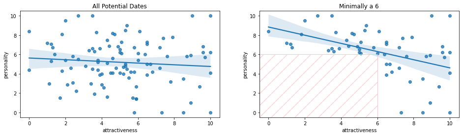

```python
np.random.seed(68)
potential_partner_df = pd.DataFrame(np.round(multivariate_normal(mean=[5,5],cov=[[6,0],[0,6]],size=100),1, ),
                 columns = ["attractiveness", "personality"])
potential_partner_df = potential_partner_df.applymap(lambda x: 0 if x < 1 else x) #Using applymap() we convert all x values in the dataframe smaller than 1 to 0
potential_partner_df = potential_partner_df.applymap(lambda x: 10 if x > 10 else x) #Using applymap() we convert all x values in the dataframe greater than 10 to 10

fig, axarr = plt.subplots(1, 2, figsize=(16, 4))
plt.subplot(1,2,1)
_ = sns.regplot(x = "attractiveness", y = "personality", data=potential_partner_df) #sns.regplot() is used to plot data and a linear regression model fit
#sns is seaborn, a Python library used for data visualization and exploratory data analysis.
#We chose seaborn as it works well with dataframes.

#Overall scale of all potential dates
plt.title("All Potential Dates")
plt.subplot(1,2,2)
plt.xlim([-0.5,10.5])
plt.ylim([-0.5,10.5])
sns.regplot(x = "attractiveness",
                y = "personality",
                data=potential_partner_df[np.logical_or(potential_partner_df.attractiveness > 6, potential_partner_df.personality > 6)])

#Scale of dates among Mary's minimum expectations
plt.title('Minimally a 6')
plt.xlim([-0.5,10.5])
plt.ylim([-0.5,10.5])
_ = plt.fill_between(x=[-0.5,6], y1=[6,6], y2=[-0.5,-0.5], hatch='/', edgecolor="pink", facecolor="none")
```

From the graph modelled above, it is apparent that the biased sampling present caused a false correlation between personality and attractiveness. When considering all males in the dating site, there is no conclusive association between attractiveness and personality of males. However, when sampling data is excluded as Mary only considers potential partners that meets her expectations of a minimum score of 6 on either the personality or attractiveness scale. As a result, one who is lacking on either criteria would have to score higher on the other scale to compensate. This causes a false association between personality and attractiveness to arise.

# **Birthday Paradox**

In probability, the birthday paradox asks for the probability that, in a set of n randomly chosen people, at least two will share a birthday. Counterintuitively, the probability of a shared birthday exceeds 50% in a group of only 23 people. However, when the group size increases to at least 70 people, there is a 99.9% chance of a coincidental birthday.

The birthday paradox is a veridical paradox: it appears wrong but is in fact true. It sounds counterintuitive as it takes a full 366 (365 days in a year + 1) people to have a 100% chance of a shared birthday. While it may seem surprising that only 23 individuals are required to reach a 50% probability of a shared birthday, this result is more understandable by considering that the comparisons of birthdays will be made between every possible pair of individuals. With 23 individuals, there are (23 × 22) / 2 = 253 pairs to consider, which is well over half the number of days in a year.

It is important to note that the birthday paradox is valid only with these assumptions in mind:

1. The year has 365 days - not a leap year.
2. All 365 birthdays are equally likely.

Considering this, let us assume a situation where there is n number of people in a room, where n ranges from a minimum of 2 individuals to a maximum of 100. All individuals have a random birthday, and therefore, the number of possible birthdays would be 365, the number of days in a given year. The code below attempts to visualise the probability of a randomly selected individual in the room having a birthday that coincides with another, in both contexts where there are 23 people and 70 people in the room respectively.

**Visualizing the Birthday Paradox**

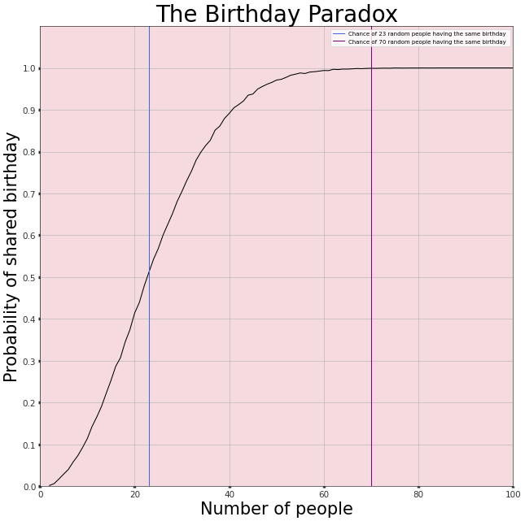

```python
#Below are a list of constants we will use for our example
MIN_NUM_PEOPLE = 2
MAX_NUM_PEOPLE = 100
NUM_POSSIBLE_BIRTHDAYS = 365 #In our example, we do not consider leap years, so there are 365 possible birthdays.
NUM_TRIALS = 10000 #We run the function 10000 times to produce a smooth graph.

#The function generate_n_birthdays gives us n numbers of random birthdays.
def generate_n_birthdays(n):
    birthdays = list(np.random.randint(1, NUM_POSSIBLE_BIRTHDAYS+1, n)) #Add the random birthdays generated to the birthdays list.
    return birthdays

#The function samebday checks if there are birthdays that fall on the same day (coincidence) within the birthdays list.
def samebday(birthdays):
    unique_birthdays = set(birthdays) #This turns the birthdays list into a set, because there cannot be duplicates within a set.
    number_of_birthdays = len(birthdays)
    number_of_unique_birthdays = len(unique_birthdays)
    coincidence = (number_of_birthdays != number_of_unique_birthdays) #Checks if the two variables are equal to each other.
                                                                      #!= returns True if the two variables are not equal.
                                                                      #True means there are less unique birthdays than birthdays, suggests that duplicates were dropped.
    return coincidence

#The function estimate_of_probability returns the estimated probability of at least one birthday coincidence.
def estimate_of_probability(n):
    number_of_samebday = 0
    for i in range(NUM_TRIALS):
        birthdays = generate_n_birthdays(n)
        has_coincidence = samebday(birthdays)
        if has_coincidence:
            number_of_samebday += 1

    probability = number_of_samebday / NUM_TRIALS
    return probability

#The function estimate_of_probability_for_range returns the estimated probability of at least one birthday coincidence for the range 2 to 100.
def estimate_of_probability_for_range(ns):
    n_probabilities = []

    for n in ns:
        probability = estimate_of_probability(n)
        n_probabilities.append(probability)

    return n_probabilities

#Plotting the graph
ns = range(MIN_NUM_PEOPLE, MAX_NUM_PEOPLE + 1) #Second argument is MAX_NUM_PEOPLE + 1, or else the last value in the range would be 100 – 1 (instead of 100).
n_probabilities = estimate_of_probability_for_range(ns) #Stores estimated probabilities for all n's in the list n_probabilities.


fig, ax = plt.subplots(figsize=(15, 15), dpi=50)
ax.set_facecolor('#F5DADF')
ax.xaxis.set_tick_params(width=5, color='#2d3233')
ax.yaxis.set_tick_params(width=5, color='#2d3233')
ax.plot(ns,n_probabilities,color='black')

plt.xticks(fontsize=15, color='#2d3233')
y_range = list(np.arange(0, 1.1, 0.1))
plt.yticks(y_range, fontsize=15, color='#2d3233')
plt.grid()
plt.xlim([0, 100])
plt.ylim([0, 1.1])
plt.axvline(x = 23, color = 'royalblue', label = 'Chance of 23 random people having the same birthday ') #Adds a vertical line across the axes.
plt.axvline(x = 70, color = 'purple', label = 'Chance of 70 random people having the same birthday ')
plt.legend(bbox_to_anchor=(1,1),loc = 'upper right')
plt.title("The Birthday Paradox", fontsize=40,color='black' )
plt.xlabel('Number of people', fontsize=30, color='black')
plt.ylabel('Probability of shared birthday', fontsize=30, color='black')

plt.show()
```

**Applications and implications**

Real-world applications for the birthday paradox include a cryptographic attack called the birthday attack, which uses this probabilistic model to reduce the complexity of finding a collision for a hash function, as well as calculating the approximate risk of a hash collision existing within the hashes of a given size of the population.

Another implication of the birthday paradox can be portrayed in the field of satellite collisions and space junk. The chances of two orbiting objects colliding with each other over the course of one year are infinitely small. However, since there are around 5,500 satellites and approximately 900,000 objects orbiting in space, collisions occur more regularly than you think. Governments around the world can track the larger pieces of space junk, allowing avoidance manoeuvres to take place to decrease potential collisions among satellites. However, with approximately 20,000 close approaches per week, this becomes an increasingly difficult and costly procedure that the governments must consider.

# **Conclusion**

The Simpson’s Paradox, Berkson’s Paradox, and Birthday Paradox are 3 common paradoxes in data science. Now, easy-to-use statistical software and analytic tools that give us results instantly discourage us from making the effort to understand such paradoxes. However, being able to use Python to model them and find possible generalisable patterns amongst multiple datasets in this project allows us to highlight the importance of understanding data and its limitations, and be aware of hidden biases and variables present in data to draw accurate conclusions.

# **References**

Artificial Datasets with Scikit-Learn, https://python-course.eu/machine-learning/artificial-datasets-with-scikit-learn.php (accessed Apr 1, 2022).

Berkson's paradox. https://en.wikipedia.org/wiki/Berkson%27s_paradox (accessed Apr 1, 2022).

Covid-19 case surveillance public use data. https://data.cdc.gov/Case-Surveillance/COVID-19-Case-Surveillance-Public-Use-Data/vbim-akqf/data (accessed Apr 1, 2022).

Farnworth, R. The Birthday Paradox https://towardsdatascience.com/the-birthday-paradox-ec71357d45f3 (accessed 2022 -04 -01).

Home. https://stats.oarc.ucla.edu/other/mult-pkg/whatstat/what-is-the-difference-between-categorical-ordinal-and-interval-variables/ (accessed Apr 1, 2022).

Katari, K. Seaborn: Python https://towardsdatascience.com/seaborn-python-8563c3d0ad41 (accessed 2022 -04 -01).

Simpson's paradox. https://en.wikipedia.org/wiki/Simpson's_paradox (accessed Apr 1, 2022).

Simpson's paradox. https://www.britannica.com/topic/Simpsons-paradox (accessed Apr 1, 2022).

Simpson's Paradox in COVID-19 Case Fatality Rates: A Mediation Analysis of Age-Related Causal Effects https://www.computer.org/csdl/journal/ai/2021/01/09404149/1sNm718j25W (accessed 2022 -04 -01).

Simpson’s Paradox and Interpreting Data | by Tom Grigg | Towards Data Science https://towardsdatascience.com/simpsons-paradox-and-interpreting-data-6a0443516765 (accessed 2022 -04 -01).

Understanding the birthday paradox. https://betterexplained.com/articles/understanding-the-birthday-paradox/ (accessed Apr 1, 2022).

Visualizing Simpson’s Paradox https://kaggle.com/wduckett/visualizing-simpson-s-paradox (accessed 2022 -04 -01).